# Age diversity of Monkfish

Ricky Tabandera

12 Feb 2021

## Age diversity

Diversity in age measurements of a stock is a useful indicator of several factors relating to fishing pressure and recruitment. A decrease in diversity can be due to either truncation, the lack of older or younger ages. Diversity changes as a funtion of an increase of a single/few ages relative to the usual stock age structure or as more ages become less reprisented. Diagnostic plots of age are constructed below using fisheries independent data from Survdata.

The age determination method for monkfish has not been validated, and the anatomic structure used has changed through time. In addition these stocks display a high degree of sexual dimorphisms making fitting of single growth curves unreliable. This results a high degree of uncertainty in assessing the age structure of the stock and the effects of fishing pressure.

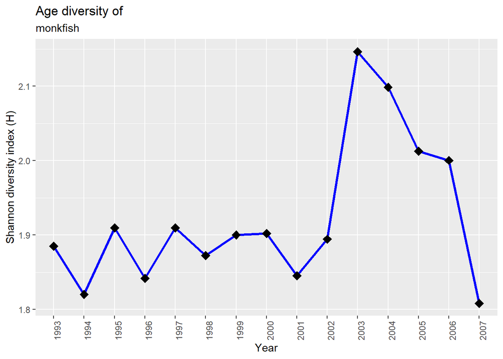

## Density plots of age

Age distribution across years of survey data of monkfish. These plots can help identify strong year classes of recruits and how these classes persist in the fishery

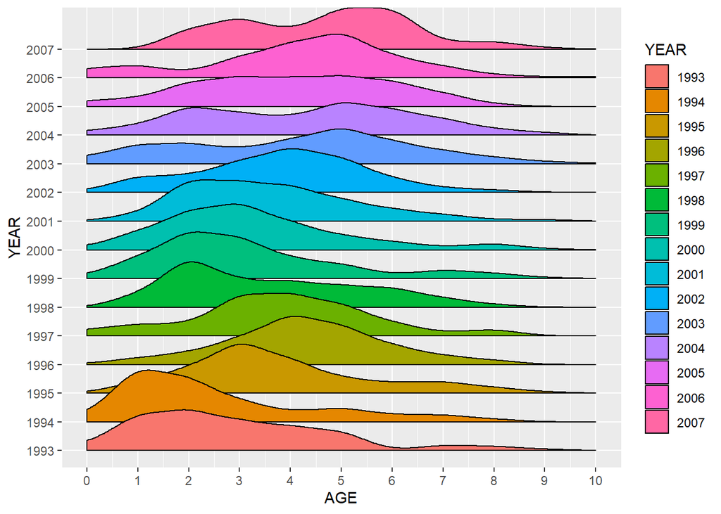